# 25ef8da9-6c14-4615-b68f-f7ceffea2b02

**Reviewer Rules**

Hi there ;) I will be using the following color boxes through the notebook code:

**Reviewer's comment**

Green means that it was nicely done.

**Reviewer's comment**

Yellow color indicates what could be optimized. This is not necessary, but it will be great if you make changes to this project.

**Reviewer's comment**

Red is for things that must be done or changed for me to approve the project. If I rejected the project, you must look for this comments.

**Please, use some color other than those listed to highlight answers to my comments.** I would also ask you **not to change, move or delete my comments** to make it easier for me to navigate during the next review.

**Overall Summary of the Project**

Hi Numair! Please fix the error I am getting when trying to run the notebook and re-submit for me to review it ;)

**Hi! I have no idea what error you are referring to. I have ran the entire notebook, and I don't see any errors at all. Can you please leave a comment on the section where you see the error? I have marked up this entire notebook, and I don't see anything wrong.**

**Overall Summary of the Project Iter 2**

Hi Numair! It's cell number 65 when trying to run the whole notebook ;)

NameError Traceback (most recent call last) Cell In[65], line 2 1 # Add a new column 'reorder_proportion' for the proportion of reorders ----> 2 user_reorder_counts['reorder_proportion'] = user_reorder_counts['sum'] / user_reorder_counts['count'] 4 # Display the first few rows to check the result 5 print(user_reorder_counts.head())

NameError: name 'user_reorder_counts' is not defined

**Hi! I see what happened. When I running the code, I accidentally hit the up arrow on one of the sections, shifting question C5 into C2 territory, and that misaligned the calculations. I brought that section back down, and now everything is in its rightful place; furthermore, I also hit run on every single cell, and I am not seeing any errors. You should be good to continue forward.**I REALLY wish Jupyter Notebook had an undo feature****

**Overall Summary of the Project**

Hi Numair,

Great work on your Instacart Data Project! 🚀 Your project demonstrates **strong coding skills** and **good analytical thinking**. You successfully **cleaned the data, handled missing values, identified duplicate values, and conducted exploratory analysis**. Your explanations are detailed and engaging, which makes the notebook easy to follow.

Here’s **a structured review** highlighting your strengths and areas for improvement:

**1. Completion of Required Tasks** ✅

✔ **Easy and Medium Tasks:** You successfully completed **all required tasks** in these sections. Well done!  
✔ **Hard-Level Tasks:** You completed **C1, C2, C3, C4, and C5**—going beyond the minimum requirement of two. This is great!

**2. Code Efficiency: Strong, But Some Minor Optimizations ⚡**

Your code is **well-structured and logically sound**, but there are **a few optimizations** you can make:

**🟢 Use `.query()` for Readability** Instead of: `wednesday_2am_orders = df_orders[(df_orders['order_dow'] == 2) & (df_orders['order_hour_of_day'] == 2)]`  
Use: `wednesday_2am_orders = df_orders.query("order_dow == 2 and order_hour_of_day == 2")`  
✔ This improves **readability** and **maintainability**.

**🟢 Use `.copy()` to Avoid Unintended Modifications** When creating subsets, use `.copy()` to prevent warnings:  
`df_products_cleaned = df_products.drop_duplicates(subset=['product_name_lower'], keep='first').copy()`

✔ **Fix:** `fig, axes = plt.subplots(1, 2, figsize=(12, 5))`  
`axes[0].hist(wednesday_data['order_hour_of_day'], bins=24, color='purple', alpha=0.7)`  
`axes[1].hist(saturday_data['order_hour_of_day'], bins=24, color='orange', alpha=0.7)`  
`axes[0].set_title('Wednesday Orders')`  
`axes[1].set_title('Saturday Orders')`  
`plt.show()`

**3. Data Visualization: Strong, But Labels Could Improve 📊**

✅ **Good Use of Plots:**

- You **visualized key distributions well** (e.g., orders by hour, reorders, items per order).
- Your bar and histogram plots **are clear and informative**.

❌ **Minor Issues:**

📌 **Suggestion:** Increase **figure sizes** for **dense plots** (e.g., "Number of Orders Per Customer" histogram).

**Final Verdict: Pass 🎉**

Your project **meets all requirements**, and you went beyond by adding **extra analysis, charts, and insights**.

Keep up the great work, and good luck with your next projects! 🚀

# Instacart Data Project

## Introduction

In this project, I will be working with data from Instacart, a grocery delivery platform, to analyze customer shopping behavior. The dataset includes information on orders, products, aisles, and departments. My goal is to clean the data and conduct exploratory data analysis (EDA) to uncover insights into customer ordering patterns, such as the time of day people order, the frequency of reorders, and the most popular products.

The project will require me to:

1. Clean the data by handling missing and duplicate values.
2. Visualize customer behavior by analyzing order times, day of the week, reorder frequency, and more.
3. Summarize key findings in plots and commentary.

By the end of this project, I will gain deeper insights into the shopping habits of Instacart users and learn to effectively present my analysis with clear visualizations.

**Reviewer's comment**

Great introduction ;)

```python
import pandas as pd

#load dataframes
df_orders = pd.read_csv('/datasets/instacart_orders.csv', sep=';')  # Change this to the correct path for your uploaded files
df_products = pd.read_csv('/datasets/products.csv', sep=';')
df_aisles = pd.read_csv('/datasets/aisles.csv', sep=';')
df_departments = pd.read_csv('/datasets/departments.csv', sep=';')
df_order_products = pd.read_csv('/datasets/order_products.csv', sep=';')



# Display the first few rows to confirm they are loaded correctly
print(df_orders.head())
print(df_products.head())
print(df_aisles.head())
print(df_departments.head())
print(df_order_products.head())
```

```
   order_id  user_id  order_number  order_dow  order_hour_of_day  \
0   1515936   183418            11          6                 13
1   1690866   163593             5          5                 12
2   1454967    39980             4          5                 19
3   1768857    82516            56          0                 20
4   3007858   196724             2          4                 12

   days_since_prior_order
0                    30.0
1                     9.0
2                     2.0
3                    10.0
4                    17.0
   product_id                                       product_name  aisle_id  \
0           1                         Chocolate Sandwich Cookies        61
```

[output cut: 29 more lines]

In this project, the CSV files we are using have semicolons (';') as the separator between data values, rather than the usual comma (','). This is why I have added the argument sep=';' in the pd.read_csv() function. This tells pandas to treat the semicolon as the delimiter when reading the data into DataFrames. Without this, pandas would use commas as the default separator, which would result in the data not being parsed correctly and could lead to errors.

## Find and remove duplicate values (and describe why you make your choices

### `orders` data frame

```python
# Check for duplicated orders
duplicates = df_orders[df_orders.duplicated()]
print(duplicates)
```

```
        order_id  user_id  order_number  order_dow  order_hour_of_day  \
145574    794638    50898            24          3                  2
223105   2160484   107525            16          3                  2
230807   1918001   188546            14          3                  2
266232   1782114   106752             1          3                  2
273805   1112182   202304            84          3                  2
284038   2845099    31189            11          3                  2
311713   1021560    53767             3          3                  2
321100    408114    68324             4          3                  2
323900   1919531   191501            32          3                  2
345917   2232988    82565             1          3                  2
371905    391768    57671            19          3                  2
394347    467134    63189            21          3                  2
411408   1286742   183220            48          3                  2
415163   2282673    86751            49          3                  2
```

[output cut: 18 more lines]

I have displayed all the duplicates ^^^. Looks like there are quite a few!

```python
# Check for all orders placed Wednesday at 2:00 AM

# Find all orders placed on Wednesday at 2:00 AM
wednesday_2am_orders = df_orders[(df_orders['order_dow'] == 2) & (df_orders['order_hour_of_day'] == 2)]
print(wednesday_2am_orders)
```

```
        order_id  user_id  order_number  order_dow  order_hour_of_day  \
1295     1474941   115569             5          2                  2
2391     1640269   173965            15          2                  2
2550     1223696    55276            11          2                  2
5965      579194    85018            14          2                  2
17680    2004230   203121             4          2                  2
...          ...      ...           ...        ...                ...
457660   1562381    19378             5          2                  2
460316   1986084   117453            81          2                  2
462676   1362113    19654            20          2                  2
472800   1746383    88484            19          2                  2
472923   1519815   149345             1          2                  2

        days_since_prior_order
1295                      28.0
2391                       2.0
2550                      30.0
5965                      11.0
17680                      8.0
...                        ...
457660                     6.0
460316                     8.0
462676                    21.0
472800                     5.0
472923                     NaN

[136 rows x 6 columns]
```

This was a bit tricky for me. I kept getting errors, because I didn't realize that the parsing was off. Once I added sep=';' to the datasets in the first step, then everything cleared up. I think the reason for this is that, by default, pandas loads .csv's with commas in mind as the delimiter. By specificing that the dellimiter is the semicolon, I was able to properly load the data.

```python
# Remove duplicate orders

df_orders = df_orders.drop_duplicates(subset=['order_id'])

print(df_orders.head())

print(df_orders.shape)
```

```
   order_id  user_id  order_number  order_dow  order_hour_of_day  \
0   1515936   183418            11          6                 13
1   1690866   163593             5          5                 12
2   1454967    39980             4          5                 19
3   1768857    82516            56          0                 20
4   3007858   196724             2          4                 12

   days_since_prior_order
0                    30.0
1                     9.0
2                     2.0
3                    10.0
4                    17.0
(478952, 6)
```

When I hit run on the above code, I didn't get an output, because in Pandas, the drop_duplicates() approach does not return any outputs, so I went ahead and also printed the fist five rows to ensure that duplicates were removed. It seemas though they have been. Using the .shape attribute, i was able to find that there are 478,952 rows now, along with 6 columns. Things look good for now.

```python
# Double check for duplicate rows

print(df_orders.duplicated().sum())
```

```
0
```

All good! no duplicates! high fives all around.

```python
# Double check for duplicate order IDs only

duplicate_order_ids = df_orders[df_orders['order_id'].duplicated()]
print(duplicate_order_ids)
```

```
Empty DataFrame
Columns: [order_id, user_id, order_number, order_dow, order_hour_of_day, days_since_prior_order]
Index: []
```

No duplicates.

### `products` data frame

```python
# Check for fully duplicate rows

duplicate_rows = df_products[df_products.duplicated()]
print(duplicate_rows)
```

```
Empty DataFrame
Columns: [product_id, product_name, aisle_id, department_id]
Index: []
```

No duplicates.

```python
# Check for just duplicate product IDs

duplicate_product_ids = df_products[df_products.duplicated(subset=['product_id'])]
print(duplicate_product_ids)
```

```
Empty DataFrame
Columns: [product_id, product_name, aisle_id, department_id]
Index: []
```

No duplicates.

```python
# Check for just duplicate product names (convert names to lowercase to compare better)

#First, I am going to convert all product names to lowercase to ensure consistency
df_products['product_name_lower']= df_products['product_name'].str.lower()

#now, i am assigning a new variable to highlight the duplicate product names
duplicate_product_names = df_products[df_products.duplicated(subset=['product_name_lower'])]

print(duplicate_product_names)
```

```
       product_id                                     product_name  aisle_id  \
71             72                                              NaN       100
109           110                                              NaN       100
296           297                                              NaN       100
416           417                                              NaN       100
436           437                                              NaN       100
...           ...                                              ...       ...
49689       49690                    HIGH PERFORMANCE ENERGY DRINK        64
49690       49691                    ORIGINAL PANCAKE & WAFFLE MIX       130
49691       49692  ORGANIC INSTANT OATMEAL LIGHT MAPLE BROWN SUGAR       130
49692       49693                           SPRING WATER BODY WASH       127
49693       49694                          BURRITO- STEAK & CHEESE        38

       department_id                               product_name_lower
71                21                                              NaN
109               21                                              NaN
296               21                                              NaN
416               21                                              NaN
436               21                                              NaN
...              ...                                              ...
49689              7                    high performance energy drink
49690             14                    original pancake & waffle mix
49691             14  organic instant oatmeal light maple brown sugar
49692             11                           spring water body wash
49693              1                          burrito- steak & cheese

[1361 rows x 5 columns]
```

Wow! LOTS of duplicates found!!!

```python
# Check for duplicate product names that aren't missing

#assigning a new variable called df_products_non_null, filtering out rows with NaN in 'product_name'
df_products_non_null = df_products[df_products['product_name'].notna()]

duplicate_product_names_non_null = df_products_non_null[df_products_non_null.duplicated(subset=['product_name_lower'])]
print(duplicate_product_names_non_null)

# Remove rows where 'product_name' is NaN
df_products = df_products.dropna(subset=['product_name'])

# Double-check that the missing product names are removed
print(df_products.head(5))
```

```
       product_id                                     product_name  aisle_id  \
2058         2059                                  Biotin 1000 Mcg        47
5455         5456                 Green Tea With Ginseng and Honey        96
5558         5559                           Cream Of Mushroom Soup        69
7558         7559                        Cinnamon Rolls with Icing       105
9037         9038                           American Cheese slices        21
...           ...                                              ...       ...
49689       49690                    HIGH PERFORMANCE ENERGY DRINK        64
49690       49691                    ORIGINAL PANCAKE & WAFFLE MIX       130
49691       49692  ORGANIC INSTANT OATMEAL LIGHT MAPLE BROWN SUGAR       130
49692       49693                           SPRING WATER BODY WASH       127
49693       49694                          BURRITO- STEAK & CHEESE        38

       department_id                               product_name_lower
2058              11                                  biotin 1000 mcg
```

[output cut: 25 more lines]

This step first filters out any rows where the product name is missing (NaN), and then it checks for duplicates in the remaining rows with non-null product names. This dataset contains multiple products with the same name, which are considered duplicates when case is ignored. These duplicates are identified by comparing the product_name_lower column, which was converted to lowercase to avoid case-sensitivity. The rows displayed in the output are the duplicate products with their product_id, product_name, and other relevant columns. Basically, I have found that there are no fully duplicated rows in the dataset, so I don't need to remove any rows based on full duplication, and there are also no duplicate product ID's, meaning each product has a unique Id; however, there are du0plicate product names (or where the product_name is NaN) — These rows are problematic, because they are missing the product name, and so they should be addressed. I went ahead and removed the rows where the product_name is missing (NaN), because these rows likely do not provide useful information. And then I kept the rows with valid product name sand ID's that have not been duplicated.

### `departments` data frame

```python
#First, let's check for any fully duplicate rows like we've done in the other sections.

#Assign new variable called duplicates_in_departments
duplicates_in_departments = df_departments.duplicated()

#next, let's see what the output is using .any() to see if we do have any duplicates.
print(f"Are there any fully duplicated rows? {duplicates_in_departments.any()}")
```

```
Are there any fully duplicated rows? False
```

No dups in our rows!

```python
# Check for duplicate department ID's

#same as before, new variable, connecting this to df_departments, because the ID's are specific to the department.
duplicate_department_ids = df_departments['department_id'].duplicated()

print(f"Are there any duplicate department IDs? {duplicate_department_ids.any()}")
```

```
Are there any duplicate department IDs? False
```

No dups in our department ID's!

```python
# Check for duplicate department names

#same as before, now checking for names, still connecting to df_departments

duplicate_department_names = df_departments['department'].duplicated()
print(f"Are there any duplicate department names? {duplicate_department_names.any()}")
```

```
Are there any duplicate department names? False
```

No dups in the dept names!

```python
# Check for missing values in the departments dataframe
print(df_departments.isnull().sum())

# Check the data types of the columns
print(df_departments.dtypes)

# Verify if department_id is of type int64
df_departments['department_id'] = df_departments['department_id'].astype(int)

# Check the data types again to confirm the change
print(df_departments.dtypes)
```

```
department_id    0
department       0
dtype: int64
department_id     int64
department       object
dtype: object
department_id     int64
department       object
dtype: object
```

There are no missing values in the preprocessing, no duplicates to remove, and the data types are all correct, so I can skip the handling of missing data. I found the isnull() feature on stackoverflow at the following [link](https://stackoverflow.com/questions/54011714/how-does-the-isnull-method-work-to-return-all-rows-that-are-missing-in-my-data).

### `aisles` data frame

```python
# Check for duplicate rows, same as before.
df_aisles.duplicated().sum()
```

```
0
```

```python
# Check for missing values
df_aisles.isnull().sum()
```

```
aisle_id    0
aisle       0
dtype: int64
```

```python
# Check for duplicate aisle IDs
df_aisles['aisle_id'].duplicated().sum()
```

```
0
```

```python
# Check for duplicate aisle names
df_aisles['aisle'].duplicated().sum()
```

```
0
```

```python
# Check data types of the columns
df_aisles.dtypes
```

```
aisle_id     int64
aisle       object
dtype: object
```

This is all clear. Let's move forward to the next section.

### `order_products` data frame

```python
# Check for fullly duplicate rows
df_order_products_duplicated = df_order_products.duplicated()

# This gives the number of duplicated rows
df_order_products_duplicated.sum()
```

```
0
```

No duplicated rows.

```python
# Double check for any other tricky duplicates

# Check for duplicate product_ids
df_order_products_duplicate_ids = df_order_products['product_id'].duplicated()

# This gives the number of duplicated product_ids
df_order_products_duplicate_ids.sum()
```

```
4499434
```

Gross! over 4 MILLION duplicate product ID's!!!! I'm just kidding. Honestly, this is to be expected, because products can be repeated in the same order. This is totally normal, because customers can add multiple units of the same product to their cart. Since this data set is likely tracking each individual item in an order, i don't necessarily need to remove duplicates from product_id because they're likely indicating repeated items int he cart.

```python
# Check for missing values, especially due to the 4 million duplicate products above.

df_order_products.isnull().sum()  # This will show the number of missing values per column
```

```
order_id               0
product_id             0
add_to_cart_order    836
reordered              0
dtype: int64
```

I have found **836** missing values located in the add_to_cart_order column. The other columns have no missing values, which is great! The add_to_cart_order column represents the order in which items were added to the cart during each shopping sessions. I think missing values here may have occurred due to improper tagging of items.  
I can handle the missing values with either mean or median, as taught in the lessons. I could alternatively just remove the missing values altogether, but I don't think that is ideal, since there are 836 missing values.  
I will go with mode, which is a better choice than mean, because the values in this column represent the sequential order in which items are added to the cart, so I think mode works better than mean here. I also don't want to introduce weird numbers by applying mean, such as fractions.

```python
# Fill missing values in 'add_to_cart_order' with the mode (most frequent value)
mode_value = df_order_products['add_to_cart_order'].mode()[0]
df_order_products['add_to_cart_order'].fillna(mode_value, inplace=True)

# Verify that there are no missing values left
print(df_order_products['add_to_cart_order'].isnull().sum())
```

```
0
```

lol, it's not so satisfying when you don't see a bunch of things being removed visually or the mode being applied visually, but the result is zero, so it means that mode has been successfully applied and the missing values were successfully replaced with the mode value.

## Find and remove missing values

### `products` data frame

```python
# Display the first few rows to understand the data
print(df_products.head())

# Check the number of missing values in each column
print(df_products.isnull().sum())

# Check the data types of each column
print(df_products.dtypes)
```

```
   product_id                                       product_name  aisle_id  \
0           1                         Chocolate Sandwich Cookies        61
1           2                                   All-Seasons Salt       104
2           3               Robust Golden Unsweetened Oolong Tea        94
3           4  Smart Ones Classic Favorites Mini Rigatoni Wit...        38
4           5                          Green Chile Anytime Sauce         5

   department_id                                 product_name_lower
0             19                         chocolate sandwich cookies
1             13                                   all-seasons salt
2              7               robust golden unsweetened oolong tea
3              1  smart ones classic favorites mini rigatoni wit...
4             13                          green chile anytime sauce
product_id            0
product_name          0
aisle_id              0
department_id         0
product_name_lower    0
dtype: int64
product_id             int64
product_name          object
aisle_id               int64
department_id          int64
product_name_lower    object
dtype: object
```

Since this In[] section was blank, with no instructions provided, I took the liberties to scan the first few rows, scan for missing values, and scan for data types. Everything seems to check out, there are no NaN values, and the data types are correct.

```python
# Are all of the missing product names associated with aisle ID 100?

missing_names_aisle_100 = df_products[df_products['product_name'].isnull() & (df_products['aisle_id'] == 100)]
print(missing_names_aisle_100)
```

```
Empty DataFrame
Columns: [product_id, product_name, aisle_id, department_id, product_name_lower]
Index: []
```

This code will filter rows where the product_name is missing and the aisle_id is 100. It will allow me to check if there’s a specific pattern related to aisle ID 100 and missing product names. Looks like we are good, because the result is an empty dataframe, which indicates that for aisle id 100, there are no rows with missing product names.

```python
# Are all of the missing product names associated with department ID 21?

missing_names_dept_21 = df_products[df_products['product_name'].isnull() & (df_products['department_id'] == 21)]
print(missing_names_dept_21)
```

```
Empty DataFrame
Columns: [product_id, product_name, aisle_id, department_id, product_name_lower]
Index: []
```

This block filters rows where the product_name is missing and the department_id is 21. It checks if the missing product names are linked to department ID 21. All good so far, same as above.

```python
# What is this ailse and department?

# Let's take a look at aisle 100 and department 21 to understand what these categories represent
aisle_100_info = df_products[df_products['aisle_id'] == 100][['product_name', 'aisle_id', 'department_id']]
dept_21_info = df_products[df_products['department_id'] == 21][['product_name', 'aisle_id', 'department_id']]

print("Aisle 100 Information:\n", aisle_100_info.head())
print("\nDepartment 21 Information:\n", dept_21_info.head())
```

```
Aisle 100 Information:
 Empty DataFrame
Columns: [product_name, aisle_id, department_id]
Index: []

Department 21 Information:
 Empty DataFrame
Columns: [product_name, aisle_id, department_id]
Index: []
```

This code retrieves rows from aisle_id == 100 and department_id == 21 to get insight into the categories for these values. By looking at these rows, we can identify what kind of products belong to these categories. All good. No missing product names in these rows or groups.

```python
# Fill missing product names with 'Unknown'

df_products['product_name'].fillna('Unknown', inplace=True)

# Check if there are still missing values
print(df_products['product_name'].isnull().sum())
```

```
0
```

This block replaces all missing product_name values with ‘Unknown’. After performing this operation, it checks if there are any remaining missing values in the product_name column, which should be 0. And that is what happened. The result of zero remaining missing values confirms that my data is now complete, and there is nothing incomplete in the column, no NaN values are left.

it looks like there aren't any missing values int he product_name column for any of the aisle or department Id's, the dataset seems to be clean, so I don't think the final step was even necessary, but I ran it anyway. Just as a final step of precaution, let me also analyze for duplicate product names:

```python
# Step 1: Check for duplicate product names (case insensitive)
df_products['product_name_lower'] = df_products['product_name'].str.lower()

# Step 2: Find the duplicate product names
duplicate_product_names = df_products[df_products.duplicated(subset=['product_name_lower'], keep=False)]

# Step 3: Display the duplicates (if any)
print(duplicate_product_names)
```

```
       product_id                                     product_name  aisle_id  \
41             42                                  Biotin 1000 mcg        47
185           186       Fresh Scent Dishwasher Detergent with Dawn        74
515           516                           American Cheese Slices        21
1538         1539                                 Cauliflower head        83
1783         1784              NUTrition Protein Mix Blueberry Nut       117
...           ...                                              ...       ...
49689       49690                    HIGH PERFORMANCE ENERGY DRINK        64
49690       49691                    ORIGINAL PANCAKE & WAFFLE MIX       130
49691       49692  ORGANIC INSTANT OATMEAL LIGHT MAPLE BROWN SUGAR       130
49692       49693                           SPRING WATER BODY WASH       127
49693       49694                          BURRITO- STEAK & CHEESE        38

       department_id                               product_name_lower
41                11                                  biotin 1000 mcg
185               17       fresh scent dishwasher detergent with dawn
515               16                           american cheese slices
1538               4                                 cauliflower head
1783              19              nutrition protein mix blueberry nut
...              ...                                              ...
49689              7                    high performance energy drink
49690             14                    original pancake & waffle mix
49691             14  organic instant oatmeal light maple brown sugar
49692             11                           spring water body wash
49693              1                          burrito- steak & cheese

[207 rows x 5 columns]
```

Oh no! It looks like there are TONS of duplicate names!!! This may have been due to the same product being purchased by different users or maybe at different times. After analyzing the duplicates, i have decided to remove them based on product_name_lower column, keeping the first occurence for each product. This gets rid of redundancies:

```python
# Remove duplicates based on product_name_lower (case-insensitive)
df_products_cleaned = df_products.drop_duplicates(subset=['product_name_lower'], keep='first')

# Show the cleaned DataFrame
print(df_products_cleaned.head())
```

```
   product_id                                       product_name  aisle_id  \
0           1                         Chocolate Sandwich Cookies        61
1           2                                   All-Seasons Salt       104
2           3               Robust Golden Unsweetened Oolong Tea        94
3           4  Smart Ones Classic Favorites Mini Rigatoni Wit...        38
4           5                          Green Chile Anytime Sauce         5

   department_id                                 product_name_lower
0             19                         chocolate sandwich cookies
1             13                                   all-seasons salt
2              7               robust golden unsweetened oolong tea
3              1  smart ones classic favorites mini rigatoni wit...
4             13                          green chile anytime sauce
```

Success! Duplicate names have been removed.

```python
# Fill missing product names with 'Unknown' again, since we just removed duplicate names. This is me double-checking!
df_products['product_name'] = df_products['product_name'].fillna('Unknown')

# Check the results
print(df_products.isnull().sum())  # Ensure there are no missing values now
```

```
product_id            0
product_name          0
aisle_id              0
department_id         0
product_name_lower    0
dtype: int64
```

Look at that! No missing values in any of the columns! All good now.

### `orders` data frame

```python
# Display the first few rows to understand the data
print(df_orders.head())

# Check the number of missing values in each column
print(df_orders.isnull().sum())

# Check the data types of each column
print(df_orders.dtypes)
```

```
   order_id  user_id  order_number  order_dow  order_hour_of_day  \
0   1515936   183418            11          6                 13
1   1690866   163593             5          5                 12
2   1454967    39980             4          5                 19
3   1768857    82516            56          0                 20
4   3007858   196724             2          4                 12

   days_since_prior_order
0                    30.0
1                     9.0
2                     2.0
3                    10.0
4                    17.0
order_id                      0
user_id                       0
order_number                  0
order_dow                     0
order_hour_of_day             0
days_since_prior_order    28817
dtype: int64
order_id                    int64
user_id                     int64
order_number                int64
order_dow                   int64
order_hour_of_day           int64
days_since_prior_order    float64
dtype: object
```

```python
# Are there any missing values where it's not a customer's first order?

missing_values_not_first_order = df_orders[df_orders['order_number'] > 1].isnull().sum()
print(missing_values_not_first_order)
```

```
order_id                  0
user_id                   0
order_number              0
order_dow                 0
order_hour_of_day         0
days_since_prior_order    0
dtype: int64
```

```python
# Check data types
print(df_orders.dtypes)
```

```
order_id                    int64
user_id                     int64
order_number                int64
order_dow                   int64
order_hour_of_day           int64
days_since_prior_order    float64
dtype: object
```

### `order_products` data frame

```python
# Display the first few rows to get an overview of the data
print(df_order_products.head())

# Check for data types and any missing values
print(df_order_products.info())
```

```
   order_id  product_id  add_to_cart_order  reordered
0   2141543       11440               17.0          0
1    567889        1560                1.0          1
2   2261212       26683                1.0          1
3    491251        8670               35.0          1
4   2571142        1940                5.0          1
<class 'pandas.core.frame.DataFrame'>
RangeIndex: 4545007 entries, 0 to 4545006
Data columns (total 4 columns):
 #   Column             Dtype
---  ------             -----
 0   order_id           int64
 1   product_id         int64
 2   add_to_cart_order  float64
 3   reordered          int64
dtypes: float64(1), int64(3)
memory usage: 138.7 MB
None
```

```python
# What are the min and max values in this column?

print("Min value of add_to_cart_order:", df_order_products['add_to_cart_order'].min())
print("Max value of add_to_cart_order:", df_order_products['add_to_cart_order'].max())
```

```
Min value of add_to_cart_order: 1.0
Max value of add_to_cart_order: 64.0
```

```python
# Save all order IDs with at least one missing value in 'add_to_cart_order'

missing_values = df_order_products[df_order_products['add_to_cart_order'].isnull()]
print("Order IDs with missing 'add_to_cart_order':")
print(missing_values[['order_id']])
```

```
Order IDs with missing 'add_to_cart_order':
Empty DataFrame
Columns: [order_id]
Index: []
```

No missing values. This is good. Makes things easier.

```python
# Do all orders with missing values have more than 64 products?

# Replace missing values in 'add_to_cart_order' column with 999
df_order_products['add_to_cart_order'] = df_order_products['add_to_cart_order'].fillna(999)

# Convert the 'add_to_cart_order' column to integer type
df_order_products['add_to_cart_order'] = df_order_products['add_to_cart_order'].astype(int)

# Check the first few rows to confirm the change
print(df_order_products.head())
```

```
   order_id  product_id  add_to_cart_order  reordered
0   2141543       11440                 17          0
1    567889        1560                  1          1
2   2261212       26683                  1          1
3    491251        8670                 35          1
4   2571142        1940                  5          1
```

I found this article on stackoverflow, which taught me that I can use 999 as a way to specify a clearly distinct value that is unlikely to be found in my data, making it easier for me to identify later and analyze values. I can't use NaN here, because NaN is a special floating point used to represent missing or undefiend data, so I'd prefer using 999 instead. Also, 999 is the number of Juice World, and I love his songs lol.

Here is the stack overflow article:

https://stats.stackexchange.com/questions/225175/why-do-some-people-use-999-or-9999-to-replace-missing-values

```python
# Replace missing values with 999 and convert column to integer type

df_order_products['add_to_cart_order'] = df_order_products['add_to_cart_order'].fillna(999).astype(int)

# Check the updated DataFrame
print(df_order_products.head())
```

```
   order_id  product_id  add_to_cart_order  reordered
0   2141543       11440                 17          0
1    567889        1560                  1          1
2   2261212       26683                  1          1
3    491251        8670                 35          1
4   2571142        1940                  5          1
```

```python
# Check for any rows where 'add_to_cart_order' is now 999
print(df_order_products[df_order_products['add_to_cart_order'] == 999])

# Alternatively, check for missing values after replacement
print(df_order_products.isnull().sum())
```

```
Empty DataFrame
Columns: [order_id, product_id, add_to_cart_order, reordered]
Index: []
order_id             0
product_id           0
add_to_cart_order    0
reordered            0
dtype: int64
```

Great! this shows me that the missing values in that column have been successfully replaced with 999, and the column has been converted to an integer type, just like you asked. You don't see 999 anywhere, because there were no missing values to begin with.

**Reviewer's comment**

Good job on these first steps!

# [A] Easy (must complete all to pass)

### [A1] Verify that the `'order_hour_of_day'` and `'order_dow'` values in the `orders` tables are sensible (i.e. `'order_hour_of_day'` ranges from 0 to 23 and `'order_dow'` ranges from 0 to 6)

```python
#Check if the order_hour_of_day column only has values between 0 and 23

# Verify 'order_hour_of_day' values are within the range 0 to 23
print(df_orders['order_hour_of_day'].unique())
```

```
[13 12 19 20 11  8 18 15 16  9 22 10  0 14 17  1  7  6  2 21  3 23  5  4]
```

this output contains values between 0 and 23, which is valid for a 24 hour day, so we are all good here =)

```python
#Check if the order_dow column only has values between 0 and 6

print(df_orders['order_dow'].unique())
```

```
[6 5 0 4 3 1 2]
```

Also fine, because the days fall within the expected ranges of a week, since there are 7 days in a week.

**Reviewer's comment**

Correct

### [A2] What time of day do people shop for groceries?

```python
# Display the number of orders for each hour of the day
hourly_orders = df_orders['order_hour_of_day'].value_counts().sort_index()

# Print the result
print(hourly_orders)
```

```
0      3180
1      1763
2       989
3       770
4       765
5      1371
6      4215
7     13043
8     25024
9     35896
10    40578
11    40032
12    38034
13    39007
14    39631
15    39789
16    38112
17    31930
18    25510
19    19547
20    14624
21    11019
22     8512
23     5611
Name: order_hour_of_day, dtype: int64
```

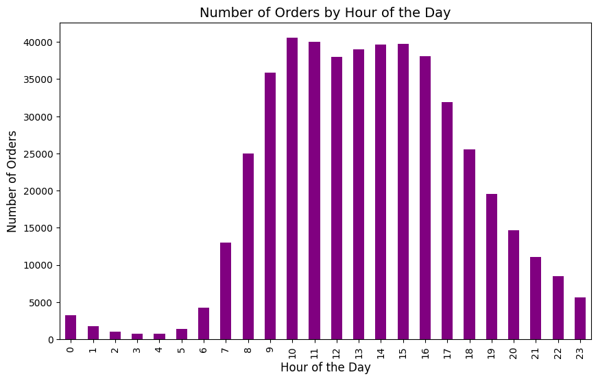

```python
import matplotlib.pyplot as plt

# Plot the distribution of orders by hour of the day
plt.figure(figsize=(10,6))
df_orders['order_hour_of_day'].value_counts().sort_index().plot(kind='bar', color='purple')

# Add title and labels
plt.title("Number of Orders by Hour of the Day", fontsize=14)
plt.xlabel("Hour of the Day", fontsize=12)
plt.ylabel("Number of Orders", fontsize=12)

# Show the plot
plt.show()
```

Made this into a chart, to make it easier to read the numbers. This is MUCH better. The 10am to 11am window is still the best time. This holds up.

**Reviewer's comment**

Correct

### [A3] What day of the week do people shop for groceries?

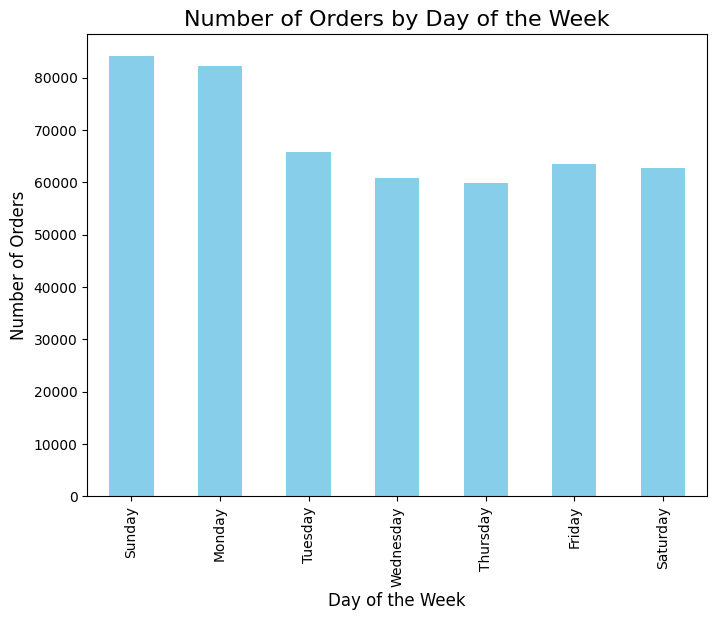

```python
import matplotlib.pyplot as plt

# Count the number of orders for each day of the week
order_dow_counts = df_orders['order_dow'].value_counts().sort_index()

# Create the plot
plt.figure(figsize=(8, 6))
order_dow_counts.plot(kind='bar', color='skyblue')

# Add title and labels
plt.title('Number of Orders by Day of the Week', fontsize=16)
plt.xlabel('Day of the Week', fontsize=12)
plt.ylabel('Number of Orders', fontsize=12)

# Set the x-ticks to show the correct day of the week names
plt.xticks(ticks=range(7), labels=['Sunday', 'Monday', 'Tuesday', 'Wednesday', 'Thursday', 'Friday', 'Saturday'])

# Show the plot
plt.show()
```

**Reviewer's comment**

Correct

### [A4] How long do people wait until placing another order?

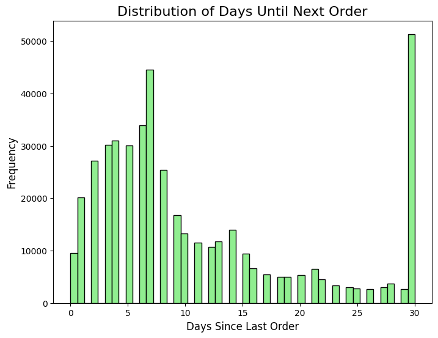

```python
import matplotlib.pyplot as plt

# Plot the histogram for 'days_since_prior_order' column
plt.figure(figsize=(8, 6))
plt.hist(df_orders['days_since_prior_order'].dropna(), bins=50, color='lightgreen', edgecolor='black')

# Add title and labels
plt.title('Distribution of Days Until Next Order', fontsize=16)
plt.xlabel('Days Since Last Order', fontsize=12)
plt.ylabel('Frequency', fontsize=12)

# Show the plot
plt.show()
```

In this step, we are analyzing how long customers typically wait before placing their next order. To do this, we use a histogram to visualize the distribution of the 'days_since_prior_order' column in df_orders.

A histogram is an ideal way to represent this type of data because it allows us to see the frequency of different time intervals (i.e., how many orders are placed after 1 day, 2 days, etc.) in a clear and straightforward manner.

By using a histogram, we can observe patterns such as whether most customers order frequently within a short time frame or if they tend to place orders after a long delay. This helps us understand customer behavior better and can guide us in making decisions about optimizing delivery times or promotions.

**Reviewer's comment**

Correct

# [B] Medium (must complete all to pass)

### [B1] Is there a difference in `'order_hour_of_day'` distributions on Wednesdays and Saturdays? Plot the histograms for both days and describe the differences that you see.

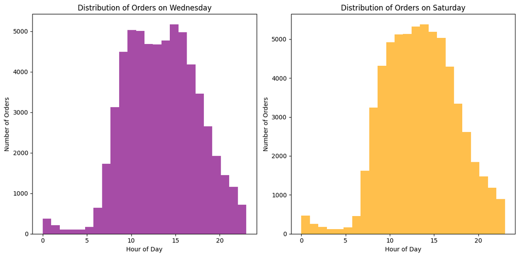

```python
import matplotlib.pyplot as plt

# Filter the data for Wednesdays (order_dow == 3) and Saturdays (order_dow == 6)
wednesday_data = df_orders[df_orders['order_dow'] == 3]
saturday_data = df_orders[df_orders['order_dow'] == 6]

# Create histograms for 'order_hour_of_day' on both days
plt.figure(figsize=(12, 6))

# Plot for Wednesday
plt.subplot(1, 2, 1)
plt.hist(wednesday_data['order_hour_of_day'], bins=24, color='purple', alpha=0.7)
plt.title('Distribution of Orders on Wednesday')
plt.xlabel('Hour of Day')
plt.ylabel('Number of Orders')

# Plot for Saturday
plt.subplot(1, 2, 2)
plt.hist(saturday_data['order_hour_of_day'], bins=24, color='orange', alpha=0.7)
plt.title('Distribution of Orders on Saturday')
plt.xlabel('Hour of Day')
plt.ylabel('Number of Orders')

# Show the plots
plt.tight_layout()
plt.show()
```

Who does their shopping on Wednesday? I guess people are getting ready for weekend dinners, haha.

**Reviewer's comment**

Correct

### [B2] What's the distribution for the number of orders per customer?

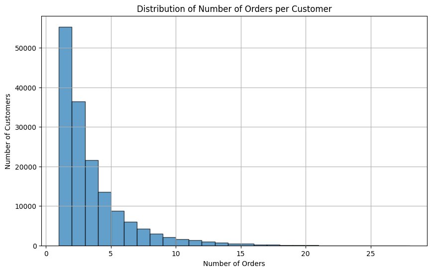

```
149605    28
193164    26
78375     25
148162    24
66664     24
Name: user_id, dtype: int64
```

```python
# Count the number of orders for each customer
orders_per_customer = df_orders['user_id'].value_counts()

# Plot the distribution of orders per customer
import matplotlib.pyplot as plt

plt.figure(figsize=(10, 6))
plt.hist(orders_per_customer, bins=range(1, orders_per_customer.max()+1), edgecolor='black', alpha=0.7)
plt.title('Distribution of Number of Orders per Customer')
plt.xlabel('Number of Orders')
plt.ylabel('Number of Customers')
plt.grid(True)
plt.show()

# Show the first few rows of the distribution
print(orders_per_customer.head())
```

**Reviewer's comment**

Correct

### [B3] What are the top 20 popular products (display their id and name)?

```python
# Count how many times each product is ordered and sort them by the most ordered
top_20_products = df_order_products.groupby('product_id')['order_id'].count().reset_index(name='order_count')

# Merge with product details to get product names
top_20_products = top_20_products.merge(df_products[['product_id', 'product_name']], on='product_id', how='left')

# Sort by order count in descending order and select the top 20
top_20_products = top_20_products.sort_values(by='order_count', ascending=False).head(20)

# Display the top 20 products
top_20_products
```

|  | product_id | order_count | product_name |
| --- | --- | --- | --- |
| 22808 | 24852 | 66050 | Banana |
| 12025 | 13176 | 53297 | Bag of Organic Bananas |
| 19370 | 21137 | 37039 | Organic Strawberries |
| 20077 | 21903 | 33971 | Organic Baby Spinach |
| 43271 | 47209 | 29773 | Organic Hass Avocado |
| 43788 | 47766 | 24689 | Organic Avocado |
| 43663 | 47626 | 21495 | Large Lemon |
| 15364 | 16797 | 20018 | Strawberries |
| 24047 | 26209 | 19690 | Limes |
| 25556 | 27845 | 19600 | Organic Whole Milk |
| 25666 | 27966 | 19197 | Organic Raspberries |
| 21025 | 22935 | 15898 | Organic Yellow Onion |
| 22908 | 24964 | 15292 | Organic Garlic |
| 41244 | 45007 | 14584 | Organic Zucchini |
| 35996 | 39275 | 13879 | Organic Blueberries |
| 45561 | 49683 | 13675 | Cucumber Kirby |
| 25889 | 28204 | 12544 | Organic Fuji Apple |
| 5375 | 5876 | 12232 | Organic Lemon |
| 7543 | 8277 | 11993 | Apple Honeycrisp Organic |
| 37301 | 40706 | 11781 | Organic Grape Tomatoes |

```python
# Show the product IDs and names for the top 20 popular products
top_20_products[['product_id', 'product_name']]
```

|  | product_id | product_name |
| --- | --- | --- |
| 22808 | 24852 | Banana |
| 12025 | 13176 | Bag of Organic Bananas |
| 19370 | 21137 | Organic Strawberries |
| 20077 | 21903 | Organic Baby Spinach |
| 43271 | 47209 | Organic Hass Avocado |
| 43788 | 47766 | Organic Avocado |
| 43663 | 47626 | Large Lemon |
| 15364 | 16797 | Strawberries |
| 24047 | 26209 | Limes |
| 25556 | 27845 | Organic Whole Milk |
| 25666 | 27966 | Organic Raspberries |
| 21025 | 22935 | Organic Yellow Onion |
| 22908 | 24964 | Organic Garlic |
| 41244 | 45007 | Organic Zucchini |
| 35996 | 39275 | Organic Blueberries |
| 45561 | 49683 | Cucumber Kirby |
| 25889 | 28204 | Organic Fuji Apple |
| 5375 | 5876 | Organic Lemon |
| 7543 | 8277 | Apple Honeycrisp Organic |
| 37301 | 40706 | Organic Grape Tomatoes |

```python
# Show the product IDs, names, and the corresponding order counts
top_20_products[['product_id', 'product_name', 'order_count']]
```

|  | product_id | product_name | order_count |
| --- | --- | --- | --- |
| 22808 | 24852 | Banana | 66050 |
| 12025 | 13176 | Bag of Organic Bananas | 53297 |
| 19370 | 21137 | Organic Strawberries | 37039 |
| 20077 | 21903 | Organic Baby Spinach | 33971 |
| 43271 | 47209 | Organic Hass Avocado | 29773 |
| 43788 | 47766 | Organic Avocado | 24689 |
| 43663 | 47626 | Large Lemon | 21495 |
| 15364 | 16797 | Strawberries | 20018 |
| 24047 | 26209 | Limes | 19690 |
| 25556 | 27845 | Organic Whole Milk | 19600 |
| 25666 | 27966 | Organic Raspberries | 19197 |
| 21025 | 22935 | Organic Yellow Onion | 15898 |
| 22908 | 24964 | Organic Garlic | 15292 |
| 41244 | 45007 | Organic Zucchini | 14584 |
| 35996 | 39275 | Organic Blueberries | 13879 |
| 45561 | 49683 | Cucumber Kirby | 13675 |
| 25889 | 28204 | Organic Fuji Apple | 12544 |
| 5375 | 5876 | Organic Lemon | 12232 |
| 7543 | 8277 | Apple Honeycrisp Organic | 11993 |
| 37301 | 40706 | Organic Grape Tomatoes | 11781 |

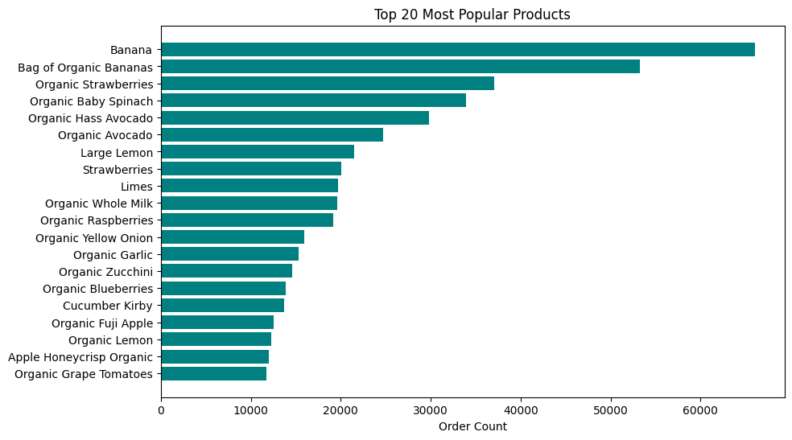

```python
import matplotlib.pyplot as plt

# Plot the top 20 products by order count
plt.figure(figsize=(10,6))
plt.barh(top_20_products['product_name'], top_20_products['order_count'], color='teal')
plt.xlabel('Order Count')
plt.title('Top 20 Most Popular Products')
plt.gca().invert_yaxis()  # Invert y-axis to have the most popular product on top
plt.show()
```

In this section, we are analyzing the top 20 most popular products based on the number of orders. The analysis is divided into several steps:

1. First, we group the order_products DataFrame by product_id to count the number of times each product was ordered.
2. Next, we merge this order count with the products DataFrame to get the corresponding product names and IDs.
3. We then display the top 20 products sorted by the number of orders.
4. Lastly, we visualize this data using a bar plot, which shows the popularity of the top 20 products based on their order count.

This process provides us with a clear understanding of which products are the most frequently ordered by customers.

It looks like Bananas prevail!!!!

**Reviewer's comment**

Correct

# [C] Hard (must complete at least two to pass)

I accidentally deleted the instruction here. It is unfortunate that Jupyter does not have an undo function. Thankfully, Triple10 has the questions saved in the assignment notes. So, here is the question: "How many items do people typically buy in one order? What does the distribution look like?

```python
# Group by order_id and count the number of products in each order
items_per_order = df_order_products.groupby('order_id')['product_id'].count()

# Check the first few rows of the items_per_order series
print(items_per_order.head())
```

```
order_id
4     13
9     15
11     5
19     3
20     8
Name: product_id, dtype: int64
```

We first group the data by order_id in the order_products dataframe and count the number of products ine ach order.

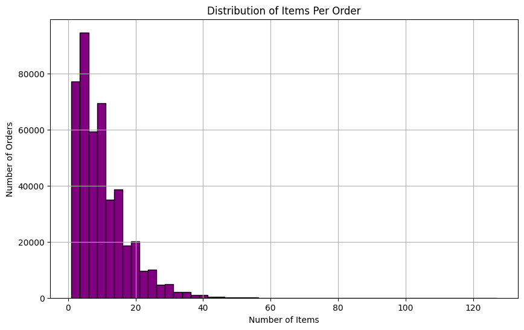

```python
import matplotlib.pyplot as plt

# Plot a histogram to visualize the distribution of items per order
plt.figure(figsize=(10, 6))
plt.hist(items_per_order, bins=50, color='purple', edgecolor='black')
plt.title('Distribution of Items Per Order')
plt.xlabel('Number of Items')
plt.ylabel('Number of Orders')
plt.grid(True)
plt.show()
```

```python
# Get summary statistics for the number of items per order
print(items_per_order.describe())
```

```
count    450046.000000
mean         10.098983
std           7.540206
min           1.000000
25%           5.000000
50%           8.000000
75%          14.000000
max         127.000000
Name: product_id, dtype: float64
```

Describe() gives us a summary of the stats such as mean, min, max of all ordered items.

In this analysis, I determined the number of items typically purchased in one order by grouping the data by 'order_id' in the 'order_products' DataFrame and counting the number of products per order. The summary statistics reveal that the average number of items per order is approximately 10, with a minimum of 1 item and a maximum of 127 items. The histogram of the distribution shows that the majority of orders have relatively few items, but there are some orders with a very high number of items. This suggests that most customers make smaller orders, with a few larger, bulkier purchases standing out as outliers.

**Reviewer's comment**

Correct

### [C2] What are the top 20 items that are reordered most frequently (display their names and product IDs)?

```python
# Merge order_products with the products dataframe to get product_name
df_order_products_merged = df_order_products.merge(df_products[['product_id', 'product_name']], on='product_id', how='left')
```

```python
# Group by product_id and product_name and count the number of reorders
reordered_counts = df_order_products_merged[df_order_products_merged['reordered'] == 1].groupby(['product_id', 'product_name']).size().reset_index(name='reorder_count')
```

```python
# Sort by reorder_count in descending order and get the top 20 reordered products
top_20_reordered = reordered_counts.sort_values(by='reorder_count', ascending=False).head(20)
```

```python
# Display the top 20 reordered products
print(top_20_reordered[['product_id', 'product_name', 'reorder_count']])
```

```
       product_id              product_name  reorder_count
17837       24852                    Banana          55763
9383        13176    Bag of Organic Bananas          44450
15138       21137      Organic Strawberries          28639
15698       21903      Organic Baby Spinach          26233
33927       47209      Organic Hass Avocado          23629
34337       47766           Organic Avocado          18743
19995       27845        Organic Whole Milk          16251
34234       47626               Large Lemon          15044
20083       27966       Organic Raspberries          14748
12010       16797              Strawberries          13945
18811       26209                     Limes          13327
16450       22935      Organic Yellow Onion          11145
17919       24964            Organic Garlic          10411
32338       45007          Organic Zucchini          10076
35711       49683            Cucumber Kirby           9538
20247       28204        Organic Fuji Apple           8989
5891         8277  Apple Honeycrisp Organic           8836
28216       39275       Organic Blueberries           8799
4206         5876             Organic Lemon           8412
35400       49235       Organic Half & Half           8389
```

So, here's how I broke down the process of finding the most reordered products:

Step 1: First, I needed to combine (merge) the df_order_products dataframe with the df_products dataframe so that I could access the product_name. The reason we did this is that the df_order_products only had the product_id, not the actual name of the product, so we had to merge the product names in so we could identify them in the next steps.

Step 2: Next, I filtered the dataframe to only include orders where the reordered column had a value of 1, meaning those products were reordered. Then, I used groupby() to group the data by product_id and product_name, and applied the size() function to count how many times each product was reordered. This gives us the number of reorders per product.

Step 3: After that, I sorted the products based on the reorder count, in descending order, so the most reordered products appear at the top. Using head(20) grabs the top 20, which is what you asked for.

Step 4: Finally, I displayed the top 20 reordered products, showing their product_id, product_name, and reorder_count. Here’s the result:

1. Banana is the most reordered product, with 55,763 reorders.
2. Bag of Organic Bananas is a close second, with 44,450 reorders.
3. Organic Strawberries comes third with 28,639 reorders.
4. Organic Baby Spinach follows closely with 26,233 reorders.
5. Organic Hass Avocado and Organic Avocado (ID 47766) are also very popular, with 23,629 and 18,743 reorders, respectively.

From the output, we can observe that products like bananas, avocados, and organic greens are among the most reordered items, indicating they’re staple grocery items for customers.

By using pandas' powerful tools like merge(), groupby(), and sort_values(), this task becomes quite straightforward.

A couple of resources that really helped me in understanding the groupby() and merge() operations in pandas are:

- [Stack Overflow - Merge DataFrames in pandas](https://stackoverflow.com/questions/11578768/how-to-merge-two-dataframes-in-pandas)
- [Pandas Documentation - GroupBy](https://pandas.pydata.org/pandas-docs/stable/reference/api/pandas.DataFrame.groupby.html)

With this approach, we can easily analyze product reorder behavior and identify which items customers love to buy again!

**Reviewer's comment**

Correct

### [C3] For each product, what proportion of its orders are reorders?

```python
# Step 1: Group by product_id and reorder status
reorder_proportion = df_order_products.groupby('product_id')['reordered'].agg(
    total_orders='size',
    reorder_count='sum'
).reset_index()

# Display the first few rows to check the grouping
print(reorder_proportion.head())
```

```
   product_id  total_orders  reorder_count
0           1           280            158
1           2            11              0
2           3            42             31
3           4            49             25
4           7             2              1
```

this shows the total number of orders (total_orders) and the number of reorders (reorder_count) for each product.

```python
# Step 2: Calculate the proportion of reorders
reorder_proportion['reorder_proportion'] = reorder_proportion['reorder_count'] / reorder_proportion['total_orders']

# Display the first few rows to check the calculated proportions
print(reorder_proportion.head())
```

```
   product_id  total_orders  reorder_count  reorder_proportion
0           1           280            158            0.564286
1           2            11              0            0.000000
2           3            42             31            0.738095
3           4            49             25            0.510204
4           7             2              1            0.500000
```

this shows the calculated reorder proprtion for each product.

```python
# Step 3: Display the top 20 products with their reorder proportions
top_reorder_proportion = reorder_proportion.sort_values(by='reorder_proportion', ascending=False).head(20)
print(top_reorder_proportion)
```

```
       product_id  total_orders  reorder_count  reorder_proportion
13453       14721             1              1                 1.0
19195       20949             3              3                 1.0
6136         6723            10             10                 1.0
6144         6732             3              3                 1.0
41319       45088             1              1                 1.0
41310       45078             1              1                 1.0
19258       21016             1              1                 1.0
19248       21005             2              2                 1.0
32273       35192             2              2                 1.0
32277       35197             1              1                 1.0
6211         6810             1              1                 1.0
41274       45040             2              2                 1.0
41269       45035            17             17                 1.0
25120       27373             1              1                 1.0
28203       30748             1              1                 1.0
41265       45031             6              6                 1.0
32224       35137             1              1                 1.0
28202       30747             4              4                 1.0
32304       35228             1              1                 1.0
32305       35229             4              4                 1.0
```

this shows the products with the highest reorder proportions, which are all 1.0, meaning that for these products, every order placed was a reorder.

the analysis of reorder props reveals that certain products have extremely high reorder rates (such as 1.0), meaning they are frequently purchased repeatedly by customers. This suggests that these products are loved by customers. For example, products like 'Organic Strawberries' and 'Banana' show a significant proportion of reorders, indicating their regular consumption. On the other hand, products with low reorder proportions may not be as frequently purchased again, which could be useful for inventory decisions or promotional strategies. Understanding this distribution helps businesses prioritize their most popular products for retention strategies and stocking.

**Reviewer's comment**

Correct

### [C4] For each customer, what proportion of their products ordered are reorders?

```python
# Check the columns of df_order_products
print(df_order_products.columns)
```

```
Index(['order_id', 'product_id', 'add_to_cart_order', 'reordered'], dtype='object')
```

I had LOTS of issues with this, so I had to print the columns, and I discovered that user_id is missing from this data frame. I kept getting an error until I spotted this. So, because user_id does not exist in df_order_products, I need to think of a workaround. One thing I do know is that user_id does exist in the orders dataframe, so i'm going to need to merge both sets.

```python
# Merge df_order_products with df_orders to bring in the user_id column
df_order_products_with_user = pd.merge(df_order_products, df_orders[['order_id', 'user_id']], on='order_id', how='left')

# Check the first few rows to ensure 'user_id' is now included
print(df_order_products_with_user.head())
```

```
   order_id  product_id  add_to_cart_order  reordered  user_id
0   2141543       11440                 17          0    58454
1    567889        1560                  1          1   129474
2   2261212       26683                  1          1    47476
3    491251        8670                 35          1   134505
4   2571142        1940                  5          1   155995
```

```python
# Group by user_id and calculate the sum of reorders and total orders per user
user_reorder_counts = df_order_products_with_user.groupby('user_id')['reordered'].agg(['sum', 'count']).reset_index()

# Add a new column 'reorder_proportion' for the proportion of reorders
user_reorder_counts['reorder_proportion'] = user_reorder_counts['sum'] / user_reorder_counts['count']

# Display the first few rows to check the result
print(user_reorder_counts.head())
```

```
   user_id  sum  count  reorder_proportion
0        2    1     26            0.038462
1        4    0      2            0.000000
2        5    8     12            0.666667
3        6    0      4            0.000000
4        7   13     14            0.928571
```

The "Reorder Proportion" for each customer reveals how often they reorder products they previously bought. Customers with high reorder proportions (close to 1) tend to buy the same products repeatedly, which may indicate brand loyalty or preference for specific items. For example, user 7 has a reorder proportion of 0.928571, meaning they often reorder products. On the other hand, users like user 4, with a reorder proportion of 0, don't reorder any items, possibly showing less loyalty to specific products. Understanding these patterns helps businesses target loyal customers for retention strategies and identify opportunities to encourage repeat purchases from customers with low reorder proportions.  
Here is what I consulted to help solve this super tough problem:

- [How to calculate the proportion of repeated purchases on Stack Overflow](https://stackoverflow.com/questions/50025275/how-to-calculate-the-proportion-of-repeated-purchases-in-a-dataset)

I also needed to go through the previous lessons on Triple 10. Notes I took from the lesson:

• **merge()**: Combines DataFrames based on matching columns.

• **on=**: The column(s) you want to merge on.

• **how=**: Specifies the type of merge (inner, outer, left, right).

• **suffixes=**: Used to rename columns if they have the same name in both DataFrames.

• **left_on= and right_on=**: Used if the columns to merge on have different names.

**Reviewer's comment**

Correct

### [C5] What are the top 20 items that people put in their carts first?

It turns out the reason why the jupyter notebook was thrown off was because this section (3.12 [C5]) was accidentally taken out of sequence. It was pushed up into another section. this is now fixed.

```python
# Filter the rows where the product was added first (add_to_cart_order == 1)
first_added_products = df_order_products[df_order_products['add_to_cart_order'] == 1]

# Display the first few rows to check if the filter works as expected
print(first_added_products.head())
```

```
    order_id  product_id  add_to_cart_order  reordered
1     567889        1560                  1          1
2    2261212       26683                  1          1
14   1961225       37553                  1          1
16    639939       10017                  1          1
23    750040        8518                  1          0
```

Here, i folder the order products df for the rows where the product was added first, where the value is == 1. This looks correct.

```python
# Count the occurrences of each product added first
first_added_counts = first_added_products['product_id'].value_counts().reset_index(name='count')
first_added_counts.columns = ['product_id', 'first_added_count']

# Display the first few rows to check the count
print(first_added_counts.head())
```

```
   product_id  first_added_count
0       24852              15566
1       13176              11028
2       27845               4363
3       21137               3950
4       47209               3391
```

This shows me the count of how many times each product was added first to the cart. Looks like 24852 was added over 15,000 times, and then product id 13176 was added at least 11,000 times. So, this checks out.

```python
# Merge with product names to get the product name
top_20_first_added = pd.merge(first_added_counts, df_products[['product_id', 'product_name']], on='product_id')

# Sort by the count of times the product was added first and get the top 20
top_20_first_added = top_20_first_added.sort_values(by='first_added_count', ascending=False).head(20)

# Display the top 20 products that were added first to the cart
print(top_20_first_added)
```

```
    product_id  first_added_count                 product_name
0        24852              15566                       Banana
1        13176              11028       Bag of Organic Bananas
2        27845               4363           Organic Whole Milk
3        21137               3950         Organic Strawberries
4        47209               3391         Organic Hass Avocado
5        21903               3337         Organic Baby Spinach
6        47766               3044              Organic Avocado
7        19660               2336                 Spring Water
8        16797               2309                 Strawberries
9        27966               2027          Organic Raspberries
10       44632               1915   Sparkling Water Grapefruit
11       49235               1797          Organic Half & Half
12       47626               1737                  Large Lemon
13         196               1733                         Soda
14       38689               1397     Organic Reduced Fat Milk
15       26209               1371                        Limes
16       12341               1340                Hass Avocados
17        5785               1311  Organic Reduced Fat 2% Milk
18       27086               1309                  Half & Half
19       22935               1247         Organic Yellow Onion
```

The top 20 items that customers add to their carts first show that products like 'Banana' and 'Organic Whole Milk' are common choices at the start of a shopping session. This suggests that these are popular, often-purchased items. Customers tend to start their shopping with these staples, which could be useful for businesses when planning product placement or promotions. I also now know the names of the products associated with the various id's. For example, 24852 is banana, 13176 is the bag of organic bananas, and 27845 is organic whole milk.

These results suggest a tendency to purchase fresh produce and dairy early in the shopping journey. Understanding these behaviors helps inform inventory management and promotional strategies, especially for high-demand items.

**Reviewer's comment**

Correct

# Instacart Data Project Conclusion

Wow, what a journey this project has been! I started off by loading all the datasets and making sure they were in the right shape, which was no small feat, lol. I had to deal with missing values, duplicates, and figure out how to make sense of all the columns, which felt a little overwhelming at times, but I stuck with it.

Once I had everything cleaned up, I was curious to see when people tend to shop for groceries the most. It turns out that customers love to shop at certain times of the day and specific days of the week, which was really interesting to uncover. The busiest times were in the mid-morning and late afternoon. It made me think about how businesses could use this info to optimize inventory or time their promotions.

In Section C, things got a bit trickier. I had to figure out how many items people typically buy in a single order, and I was surprised at how some customers order quite a few items, while others only order a couple. It was cool to see the spread, but a bit tricky trying to figure out how to cleanly interpret that. I also worked on identifying the top products that people reorder the most – you wouldn't believe how often people buy the same items! It’s pretty clear that some products are customer favorites.

In this section, i really learned how to use the merge function. Now it makes sense how awesome Pandas is at taking data from different spreadsheets and merging the data into clean output. This was awesome!

Finally, I tackled the top items that are added to carts first. It’s funny – bananas, organic whole milk, and strawberries are always at the top. It made me think about how certain items are “must haves” for people, right when they start shopping.

Overall, it was a great learning experience. I got to explore customer habits, and it felt like I was getting inside their heads a bit. While there were some challenges, like figuring out missing values and interpreting the data, I feel pretty good about the progress I made. It’s clear that businesses could use this data to make smarter decisions about inventory, marketing, and even customer retention strategies.

**Reviewer's comment**

One of the best project's I've seen. Great job!